# Codebook Grouped

Set up Code book options

```r
knitr::opts_chunk$set(
  warning = TRUE, # show warnings during codebook generation
  message = TRUE, # show messages during codebook generation
  error = TRUE, # do not interrupt codebook generation in case of errors,
                # usually better for debugging
  echo = TRUE  # show R code
)
ggplot2::theme_set(ggplot2::theme_bw())
```

Code book preparation

```r
library(codebook)

codebook_data <- rio::import("codebook_source/tidyset.rds")

# omit the following lines, if your missing values are already properly labelled
codebook_data <- detect_missing(codebook_data,
    only_labelled = TRUE, # only labelled values are autodetected as
                                   # missing
    negative_values_are_missing = FALSE, # negative values are missing values
    ninety_nine_problems = TRUE,   # 99/999 are missing values, if they
                                   # are more than 5 MAD from the median
    )

codebook_data <- detect_scales(codebook_data)
```

Create codebook

```r
codebook(codebook_data)
```

```
## No missing values.
```

### Metadata

#### Description

**Dataset name**: Grouped Accelerometer Standard Deviation and Mean Data by Student and Activity

This data set contains the standard deviation and mean of the original data. See the README.txt found in the original data, “sample_data/getdata_projectfiles_UCI_HAR_Dataset/UCI HAR Dataset/README.txt”, for more information.

**Metadata for search engines**

- **Spatial Coverage**: Online
- **Citation**: Davide Anguita, Alessandro Ghio, Luca Oneto, Xavier Parra and Jorge L. Reyes-Ortiz. Human Activity Recognition on Smartphones using a Multiclass Hardware-Friendly Support Vector Machine. International Workshop of Ambient Assisted Living (IWAAL 2012). Vitoria-Gasteiz, Spain. Dec 2012
- **URL**: https://github.com/rodelor97/GettingCleaningDataWeek4Project
- **Date published**: 2021-02-07
- **Creator**:

| name | value |
| --- | --- |
| 1 | Robert de Lorimier |

| x |
| --- |
| subject |
| activity |
| Time.Body.Accelerometer.Mean.X |
| Time.Body.Accelerometer.Mean.Y |
| Time.Body.Accelerometer.Mean.Z |
| Time.Body.Accelerometer.Standard.Deviation.X |
| Time.Body.Accelerometer.Standard.Deviation.Y |
| Time.Body.Accelerometer.Standard.Deviation.Z |
| Time.Gravity.Accelerometer.Mean.X |
| Time.Gravity.Accelerometer.Mean.Y |
| Time.Gravity.Accelerometer.Mean.Z |
| Time.Gravity.Accelerometer.Standard.Deviation.X |
| Time.Gravity.Accelerometer.Standard.Deviation.Y |
| Time.Gravity.Accelerometer.Standard.Deviation.Z |
| Time.Body.Accelerometer.Jerk.Mean.X |
| Time.Body.Accelerometer.Jerk.Mean.Y |
| Time.Body.Accelerometer.Jerk.Mean.Z |
| Time.Body.Accelerometer.Jerk.Standard.Deviation.X |
| Time.Body.Accelerometer.Jerk.Standard.Deviation.Y |
| Time.Body.Accelerometer.Jerk.Standard.Deviation.Z |
| Time.Body.Gyroscope.Mean.X |
| Time.Body.Gyroscope.Mean.Y |
| Time.Body.Gyroscope.Mean.Z |
| Time.Body.Gyroscope.Standard.Deviation.X |
| Time.Body.Gyroscope.Standard.Deviation.Y |
| Time.Body.Gyroscope.Standard.Deviation.Z |
| Time.Body.Gyroscope.Jerk.Mean.X |
| Time.Body.Gyroscope.Jerk.Mean.Y |
| Time.Body.Gyroscope.Jerk.Mean.Z |
| Time.Body.Gyroscope.Jerk.Standard.Deviation.X |

[output cut: 58 more lines]

#Variables

### subject

subject

#### Distribution

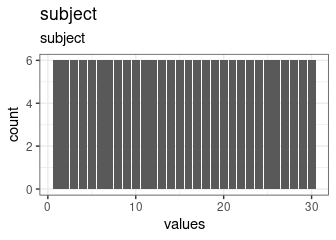

Distribution of values for subject

0 missing values.

#### Summary statistics

| name | label | data_type | n_missing | complete_rate | min | median | max | mean | sd | hist |
| --- | --- | --- | --- | --- | --- | --- | --- | --- | --- | --- |
| subject | subject | numeric | 0 | 1 | 1 | 16 | 30 | 15.5 | 8.679585 | ▇▇▇▇▇ |

### activity

activity

#### Distribution

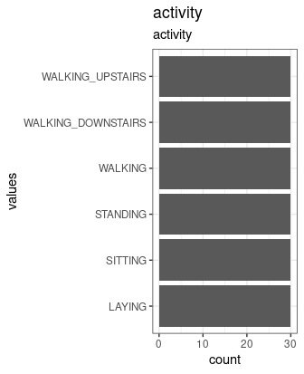

Distribution of values for activity

0 missing values.

#### Summary statistics

| name | label | data_type | n_missing | complete_rate | n_unique | empty | min | max | whitespace |
| --- | --- | --- | --- | --- | --- | --- | --- | --- | --- |
| activity | activity | character | 0 | 1 | 6 | 0 | 6 | 18 | 0 |

### Time.Body.Accelerometer.Mean.X

Time Body Accelerometer Mean X

#### Distribution

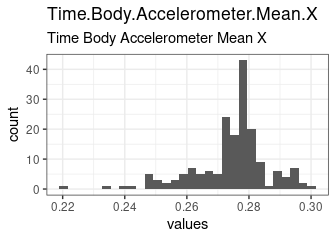

Distribution of values for Time.Body.Accelerometer.Mean.X

0 missing values.

#### Summary statistics

| name | label | data_type | n_missing | complete_rate | min | median | max | mean | sd | hist |
| --- | --- | --- | --- | --- | --- | --- | --- | --- | --- | --- |
| Time.Body.Accelerometer.Mean.X | Time Body Accelerometer Mean X | numeric | 0 | 1 | 0.22 | 0.28 | 0.3 | 0.2743027 | 0.0121646 | ▁▁▂▇▂ |

### Time.Body.Accelerometer.Mean.Y

Time Body Accelerometer Mean Y

#### Distribution

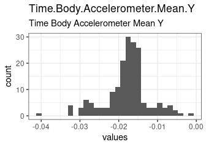

Distribution of values for Time.Body.Accelerometer.Mean.Y

0 missing values.

#### Summary statistics

| name | label | data_type | n_missing | complete_rate | min | median | max | mean | sd | hist |
| --- | --- | --- | --- | --- | --- | --- | --- | --- | --- | --- |
| Time.Body.Accelerometer.Mean.Y | Time Body Accelerometer Mean Y | numeric | 0 | 1 | -0.041 | -0.017 | -0.0013 | -0.0178755 | 0.0057712 | ▁▂▇▇▁ |

### Time.Body.Accelerometer.Mean.Z

Time Body Accelerometer Mean Z

#### Distribution

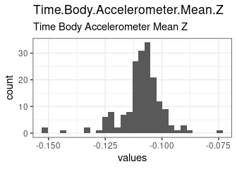

Distribution of values for Time.Body.Accelerometer.Mean.Z

0 missing values.

#### Summary statistics

| name | label | data_type | n_missing | complete_rate | min | median | max | mean | sd | hist |
| --- | --- | --- | --- | --- | --- | --- | --- | --- | --- | --- |
| Time.Body.Accelerometer.Mean.Z | Time Body Accelerometer Mean Z | numeric | 0 | 1 | -0.15 | -0.11 | -0.075 | -0.1091638 | 0.009582 | ▁▁▇▅▁ |

### Time.Body.Accelerometer.Standard.Deviation.X

Time Body Accelerometer Standard Deviation X

#### Distribution

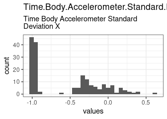

Distribution of values for Time.Body.Accelerometer.Standard.Deviation.X

0 missing values.

#### Summary statistics

| name | label | data_type | n_missing | complete_rate | min | median | max | mean | sd | hist |
| --- | --- | --- | --- | --- | --- | --- | --- | --- | --- | --- |
| Time.Body.Accelerometer.Standard.Deviation.X | Time Body Accelerometer Standard Deviation X | numeric | 0 | 1 | -1 | -0.75 | 0.63 | -0.5576901 | 0.4516911 | ▇▂▅▂▁ |

### Time.Body.Accelerometer.Standard.Deviation.Y

Time Body Accelerometer Standard Deviation Y

#### Distribution

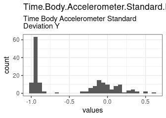

Distribution of values for Time.Body.Accelerometer.Standard.Deviation.Y

0 missing values.

#### Summary statistics

| name | label | data_type | n_missing | complete_rate | min | median | max | mean | sd | hist |
| --- | --- | --- | --- | --- | --- | --- | --- | --- | --- | --- |
| Time.Body.Accelerometer.Standard.Deviation.Y | Time Body Accelerometer Standard Deviation Y | numeric | 0 | 1 | -0.99 | -0.51 | 0.62 | -0.4604626 | 0.496565 | ▇▁▅▃▁ |

### Time.Body.Accelerometer.Standard.Deviation.Z

Time Body Accelerometer Standard Deviation Z

#### Distribution

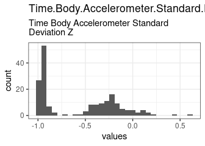

Distribution of values for Time.Body.Accelerometer.Standard.Deviation.Z

0 missing values.

#### Summary statistics

| name | label | data_type | n_missing | complete_rate | min | median | max | mean | sd | hist |
| --- | --- | --- | --- | --- | --- | --- | --- | --- | --- | --- |
| Time.Body.Accelerometer.Standard.Deviation.Z | Time Body Accelerometer Standard Deviation Z | numeric | 0 | 1 | -0.99 | -0.65 | 0.61 | -0.5755602 | 0.3955439 | ▇▂▅▁▁ |

### Time.Gravity.Accelerometer.Mean.X

Time Gravity Accelerometer Mean X

#### Distribution

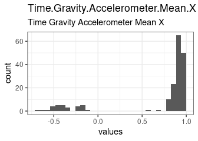

Distribution of values for Time.Gravity.Accelerometer.Mean.X

0 missing values.

#### Summary statistics

| name | label | data_type | n_missing | complete_rate | min | median | max | mean | sd | hist |
| --- | --- | --- | --- | --- | --- | --- | --- | --- | --- | --- |
| Time.Gravity.Accelerometer.Mean.X | Time Gravity Accelerometer Mean X | numeric | 0 | 1 | -0.68 | 0.92 | 0.97 | 0.6974775 | 0.4872534 | ▁▁▁▁▇ |

### Time.Gravity.Accelerometer.Mean.Y

Time Gravity Accelerometer Mean Y

#### Distribution

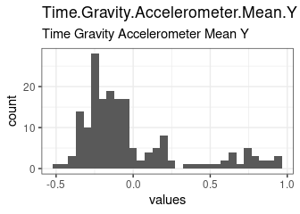

Distribution of values for Time.Gravity.Accelerometer.Mean.Y

0 missing values.

#### Summary statistics

| name | label | data_type | n_missing | complete_rate | min | median | max | mean | sd | hist |
| --- | --- | --- | --- | --- | --- | --- | --- | --- | --- | --- |
| Time.Gravity.Accelerometer.Mean.Y | Time Gravity Accelerometer Mean Y | numeric | 0 | 1 | -0.48 | -0.13 | 0.96 | -0.0162128 | 0.3452376 | ▇▇▂▁▂ |

### Time.Gravity.Accelerometer.Mean.Z

Time Gravity Accelerometer Mean Z

#### Distribution

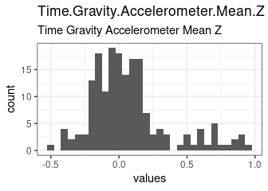

Distribution of values for Time.Gravity.Accelerometer.Mean.Z

0 missing values.

#### Summary statistics

| name | label | data_type | n_missing | complete_rate | min | median | max | mean | sd | hist |
| --- | --- | --- | --- | --- | --- | --- | --- | --- | --- | --- |
| Time.Gravity.Accelerometer.Mean.Z | Time Gravity Accelerometer Mean Z | numeric | 0 | 1 | -0.5 | 0.024 | 0.96 | 0.0741279 | 0.2887919 | ▂▇▃▁▁ |

### Time.Gravity.Accelerometer.Standard.Deviation.X

Time Gravity Accelerometer Standard Deviation X

#### Distribution

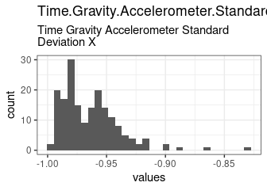

Distribution of values for Time.Gravity.Accelerometer.Standard.Deviation.X

0 missing values.

#### Summary statistics

| name | label | data_type | n_missing | complete_rate | min | median | max | mean | sd | hist |
| --- | --- | --- | --- | --- | --- | --- | --- | --- | --- | --- |
| Time.Gravity.Accelerometer.Standard.Deviation.X | Time Gravity Accelerometer Standard Deviation X | numeric | 0 | 1 | -1 | -0.97 | -0.83 | -0.9637525 | 0.0250344 | ▇▆▁▁▁ |

### Time.Gravity.Accelerometer.Standard.Deviation.Y

Time Gravity Accelerometer Standard Deviation Y

#### Distribution

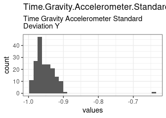

Distribution of values for Time.Gravity.Accelerometer.Standard.Deviation.Y

0 missing values.

#### Summary statistics

| name | label | data_type | n_missing | complete_rate | min | median | max | mean | sd | hist |
| --- | --- | --- | --- | --- | --- | --- | --- | --- | --- | --- |
| Time.Gravity.Accelerometer.Standard.Deviation.Y | Time Gravity Accelerometer Standard Deviation Y | numeric | 0 | 1 | -0.99 | -0.96 | -0.64 | -0.9524296 | 0.0326557 | ▇▁▁▁▁ |

### Time.Gravity.Accelerometer.Standard.Deviation.Z

Time Gravity Accelerometer Standard Deviation Z

#### Distribution

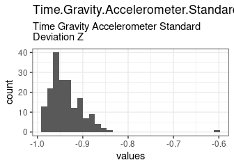

Distribution of values for Time.Gravity.Accelerometer.Standard.Deviation.Z

0 missing values.

#### Summary statistics

| name | label | data_type | n_missing | complete_rate | min | median | max | mean | sd | hist |
| --- | --- | --- | --- | --- | --- | --- | --- | --- | --- | --- |
| Time.Gravity.Accelerometer.Standard.Deviation.Z | Time Gravity Accelerometer Standard Deviation Z | numeric | 0 | 1 | -0.99 | -0.95 | -0.61 | -0.936401 | 0.0402912 | ▇▂▁▁▁ |

### Time.Body.Accelerometer.Jerk.Mean.X

Time Body Accelerometer Jerk Mean X

#### Distribution

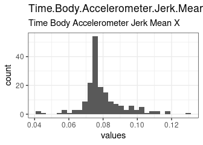

Distribution of values for Time.Body.Accelerometer.Jerk.Mean.X

0 missing values.

#### Summary statistics

| name | label | data_type | n_missing | complete_rate | min | median | max | mean | sd | hist |
| --- | --- | --- | --- | --- | --- | --- | --- | --- | --- | --- |
| Time.Body.Accelerometer.Jerk.Mean.X | Time Body Accelerometer Jerk Mean X | numeric | 0 | 1 | 0.043 | 0.076 | 0.13 | 0.0794736 | 0.012588 | ▁▇▃▂▁ |

### Time.Body.Accelerometer.Jerk.Mean.Y

Time Body Accelerometer Jerk Mean Y

#### Distribution

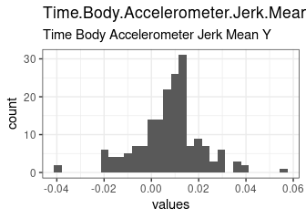

Distribution of values for Time.Body.Accelerometer.Jerk.Mean.Y

0 missing values.

#### Summary statistics

| name | label | data_type | n_missing | complete_rate | min | median | max | mean | sd | hist |
| --- | --- | --- | --- | --- | --- | --- | --- | --- | --- | --- |
| Time.Body.Accelerometer.Jerk.Mean.Y | Time Body Accelerometer Jerk Mean Y | numeric | 0 | 1 | -0.039 | 0.0095 | 0.057 | 0.0075652 | 0.0135764 | ▁▃▇▂▁ |

### Time.Body.Accelerometer.Jerk.Mean.Z

Time Body Accelerometer Jerk Mean Z

#### Distribution

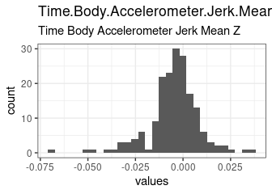

Distribution of values for Time.Body.Accelerometer.Jerk.Mean.Z

0 missing values.

#### Summary statistics

| name | label | data_type | n_missing | complete_rate | min | median | max | mean | sd | hist |
| --- | --- | --- | --- | --- | --- | --- | --- | --- | --- | --- |
| Time.Body.Accelerometer.Jerk.Mean.Z | Time Body Accelerometer Jerk Mean Z | numeric | 0 | 1 | -0.067 | -0.0039 | 0.038 | -0.0049534 | 0.0134621 | ▁▁▇▇▁ |

### Time.Body.Accelerometer.Jerk.Standard.Deviation.X

Time Body Accelerometer Jerk Standard Deviation X

#### Distribution

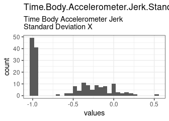

Distribution of values for Time.Body.Accelerometer.Jerk.Standard.Deviation.X

0 missing values.

#### Summary statistics

| name | label | data_type | n_missing | complete_rate | min | median | max | mean | sd | hist |
| --- | --- | --- | --- | --- | --- | --- | --- | --- | --- | --- |
| Time.Body.Accelerometer.Jerk.Standard.Deviation.X | Time Body Accelerometer Jerk Standard Deviation X | numeric | 0 | 1 | -0.99 | -0.81 | 0.54 | -0.5949467 | 0.4175865 | ▇▂▅▂▁ |

### Time.Body.Accelerometer.Jerk.Standard.Deviation.Y

Time Body Accelerometer Jerk Standard Deviation Y

#### Distribution

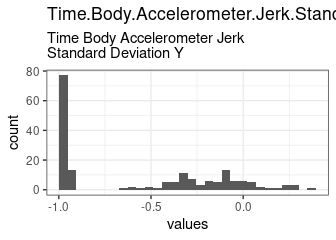

Distribution of values for Time.Body.Accelerometer.Jerk.Standard.Deviation.Y

0 missing values.

#### Summary statistics

| name | label | data_type | n_missing | complete_rate | min | median | max | mean | sd | hist |
| --- | --- | --- | --- | --- | --- | --- | --- | --- | --- | --- |
| Time.Body.Accelerometer.Jerk.Standard.Deviation.Y | Time Body Accelerometer Jerk Standard Deviation Y | numeric | 0 | 1 | -0.99 | -0.78 | 0.36 | -0.5654147 | 0.4330871 | ▇▁▃▃▁ |

### Time.Body.Accelerometer.Jerk.Standard.Deviation.Z

Time Body Accelerometer Jerk Standard Deviation Z

#### Distribution

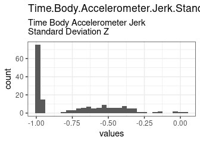

Distribution of values for Time.Body.Accelerometer.Jerk.Standard.Deviation.Z

0 missing values.

#### Summary statistics

| name | label | data_type | n_missing | complete_rate | min | median | max | mean | sd | hist |
| --- | --- | --- | --- | --- | --- | --- | --- | --- | --- | --- |
| Time.Body.Accelerometer.Jerk.Standard.Deviation.Z | Time Body Accelerometer Jerk Standard Deviation Z | numeric | 0 | 1 | -0.99 | -0.88 | 0.031 | -0.7359577 | 0.2768479 | ▇▂▃▁▁ |

### Time.Body.Gyroscope.Mean.X

Time Body Gyroscope Mean X

#### Distribution

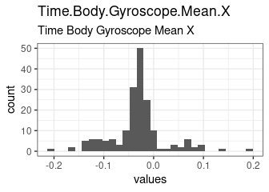

Distribution of values for Time.Body.Gyroscope.Mean.X

0 missing values.

#### Summary statistics

| name | label | data_type | n_missing | complete_rate | min | median | max | mean | sd | hist |
| --- | --- | --- | --- | --- | --- | --- | --- | --- | --- | --- |
| Time.Body.Gyroscope.Mean.X | Time Body Gyroscope Mean X | numeric | 0 | 1 | -0.21 | -0.029 | 0.19 | -0.0324372 | 0.0540518 | ▁▂▇▁▁ |

### Time.Body.Gyroscope.Mean.Y

Time Body Gyroscope Mean Y

#### Distribution

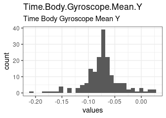

Distribution of values for Time.Body.Gyroscope.Mean.Y

0 missing values.

#### Summary statistics

| name | label | data_type | n_missing | complete_rate | min | median | max | mean | sd | hist |
| --- | --- | --- | --- | --- | --- | --- | --- | --- | --- | --- |
| Time.Body.Gyroscope.Mean.Y | Time Body Gyroscope Mean Y | numeric | 0 | 1 | -0.2 | -0.073 | 0.027 | -0.0742596 | 0.0355415 | ▁▁▇▃▁ |

### Time.Body.Gyroscope.Mean.Z

Time Body Gyroscope Mean Z

#### Distribution

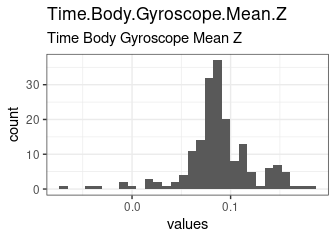

Distribution of values for Time.Body.Gyroscope.Mean.Z

0 missing values.

#### Summary statistics

| name | label | data_type | n_missing | complete_rate | min | median | max | mean | sd | hist |
| --- | --- | --- | --- | --- | --- | --- | --- | --- | --- | --- |
| Time.Body.Gyroscope.Mean.Z | Time Body Gyroscope Mean Z | numeric | 0 | 1 | -0.072 | 0.085 | 0.18 | 0.0874446 | 0.0362125 | ▁▁▃▇▂ |

### Time.Body.Gyroscope.Standard.Deviation.X

Time Body Gyroscope Standard Deviation X

#### Distribution

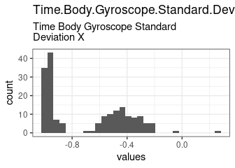

Distribution of values for Time.Body.Gyroscope.Standard.Deviation.X

0 missing values.

#### Summary statistics

| name | label | data_type | n_missing | complete_rate | min | median | max | mean | sd | hist |
| --- | --- | --- | --- | --- | --- | --- | --- | --- | --- | --- |
| Time.Body.Gyroscope.Standard.Deviation.X | Time Body Gyroscope Standard Deviation X | numeric | 0 | 1 | -0.99 | -0.79 | 0.27 | -0.6916399 | 0.2910189 | ▇▃▅▁▁ |

### Time.Body.Gyroscope.Standard.Deviation.Y

Time Body Gyroscope Standard Deviation Y

#### Distribution

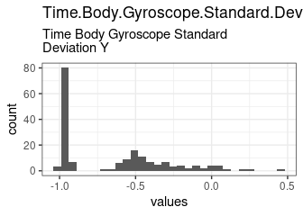

Distribution of values for Time.Body.Gyroscope.Standard.Deviation.Y

0 missing values.

#### Summary statistics

| name | label | data_type | n_missing | complete_rate | min | median | max | mean | sd | hist |
| --- | --- | --- | --- | --- | --- | --- | --- | --- | --- | --- |
| Time.Body.Gyroscope.Standard.Deviation.Y | Time Body Gyroscope Standard Deviation Y | numeric | 0 | 1 | -0.99 | -0.8 | 0.48 | -0.653302 | 0.3520252 | ▇▅▂▁▁ |

### Time.Body.Gyroscope.Standard.Deviation.Z

Time Body Gyroscope Standard Deviation Z

#### Distribution

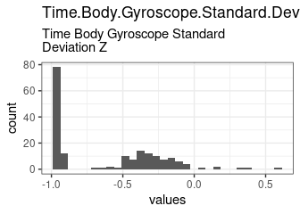

Distribution of values for Time.Body.Gyroscope.Standard.Deviation.Z

0 missing values.

#### Summary statistics

| name | label | data_type | n_missing | complete_rate | min | median | max | mean | sd | hist |
| --- | --- | --- | --- | --- | --- | --- | --- | --- | --- | --- |
| Time.Body.Gyroscope.Standard.Deviation.Z | Time Body Gyroscope Standard Deviation Z | numeric | 0 | 1 | -0.99 | -0.8 | 0.56 | -0.6164353 | 0.3730264 | ▇▂▅▁▁ |

### Time.Body.Gyroscope.Jerk.Mean.X

Time Body Gyroscope Jerk Mean X

#### Distribution

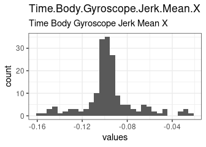

Distribution of values for Time.Body.Gyroscope.Jerk.Mean.X

0 missing values.

#### Summary statistics

| name | label | data_type | n_missing | complete_rate | min | median | max | mean | sd | hist |
| --- | --- | --- | --- | --- | --- | --- | --- | --- | --- | --- |
| Time.Body.Gyroscope.Jerk.Mean.X | Time Body Gyroscope Jerk Mean X | numeric | 0 | 1 | -0.16 | -0.099 | -0.022 | -0.0960568 | 0.0233458 | ▁▂▇▁▁ |

### Time.Body.Gyroscope.Jerk.Mean.Y

Time Body Gyroscope Jerk Mean Y

#### Distribution

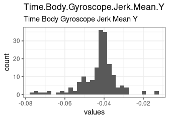

Distribution of values for Time.Body.Gyroscope.Jerk.Mean.Y

0 missing values.

#### Summary statistics

| name | label | data_type | n_missing | complete_rate | min | median | max | mean | sd | hist |
| --- | --- | --- | --- | --- | --- | --- | --- | --- | --- | --- |
| Time.Body.Gyroscope.Jerk.Mean.Y | Time Body Gyroscope Jerk Mean Y | numeric | 0 | 1 | -0.077 | -0.041 | -0.013 | -0.0426928 | 0.009532 | ▁▂▇▃▁ |

### Time.Body.Gyroscope.Jerk.Mean.Z

Time Body Gyroscope Jerk Mean Z

#### Distribution

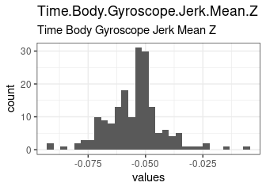

Distribution of values for Time.Body.Gyroscope.Jerk.Mean.Z

0 missing values.

#### Summary statistics

| name | label | data_type | n_missing | complete_rate | min | median | max | mean | sd | hist |
| --- | --- | --- | --- | --- | --- | --- | --- | --- | --- | --- |
| Time.Body.Gyroscope.Jerk.Mean.Z | Time Body Gyroscope Jerk Mean Z | numeric | 0 | 1 | -0.092 | -0.053 | -0.0069 | -0.0548019 | 0.012347 | ▁▅▇▁▁ |

### Time.Body.Gyroscope.Jerk.Standard.Deviation.X

Time Body Gyroscope Jerk Standard Deviation X

#### Distribution

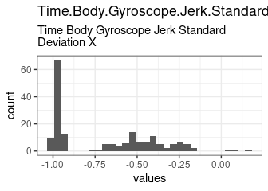

Distribution of values for Time.Body.Gyroscope.Jerk.Standard.Deviation.X

0 missing values.

#### Summary statistics

| name | label | data_type | n_missing | complete_rate | min | median | max | mean | sd | hist |
| --- | --- | --- | --- | --- | --- | --- | --- | --- | --- | --- |
| Time.Body.Gyroscope.Jerk.Standard.Deviation.X | Time Body Gyroscope Jerk Standard Deviation X | numeric | 0 | 1 | -1 | -0.84 | 0.18 | -0.7036327 | 0.3008361 | ▇▂▃▂▁ |

### Time.Body.Gyroscope.Jerk.Standard.Deviation.Y

Time Body Gyroscope Jerk Standard Deviation Y

#### Distribution

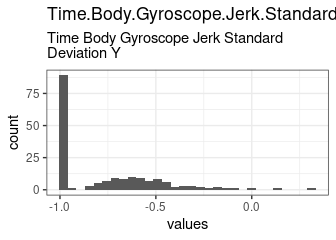

Distribution of values for Time.Body.Gyroscope.Jerk.Standard.Deviation.Y

0 missing values.

#### Summary statistics

| name | label | data_type | n_missing | complete_rate | min | median | max | mean | sd | hist |
| --- | --- | --- | --- | --- | --- | --- | --- | --- | --- | --- |
| Time.Body.Gyroscope.Jerk.Standard.Deviation.Y | Time Body Gyroscope Jerk Standard Deviation Y | numeric | 0 | 1 | -1 | -0.89 | 0.3 | -0.7635518 | 0.2672885 | ▇▃▂▁▁ |

### Time.Body.Gyroscope.Jerk.Standard.Deviation.Z

Time Body Gyroscope Jerk Standard Deviation Z

#### Distribution

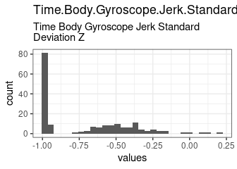

Distribution of values for Time.Body.Gyroscope.Jerk.Standard.Deviation.Z

0 missing values.

#### Summary statistics

| name | label | data_type | n_missing | complete_rate | min | median | max | mean | sd | hist |
| --- | --- | --- | --- | --- | --- | --- | --- | --- | --- | --- |
| Time.Body.Gyroscope.Jerk.Standard.Deviation.Z | Time Body Gyroscope Jerk Standard Deviation Z | numeric | 0 | 1 | -1 | -0.86 | 0.19 | -0.7095592 | 0.3045394 | ▇▃▃▁▁ |

### Time.Body.Accelerometer.Magnitude.Mean

Time Body Accelerometer Magnitude Mean

#### Distribution

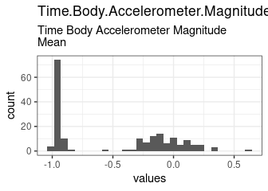

Distribution of values for Time.Body.Accelerometer.Magnitude.Mean

0 missing values.

#### Summary statistics

| name | label | data_type | n_missing | complete_rate | min | median | max | mean | sd | hist |
| --- | --- | --- | --- | --- | --- | --- | --- | --- | --- | --- |
| Time.Body.Accelerometer.Magnitude.Mean | Time Body Accelerometer Magnitude Mean | numeric | 0 | 1 | -0.99 | -0.48 | 0.64 | -0.4972897 | 0.4728834 | ▇▁▅▃▁ |

### Time.Body.Accelerometer.Magnitude.Standard.Deviation

Time Body Accelerometer Magnitude Standard Deviation

#### Distribution

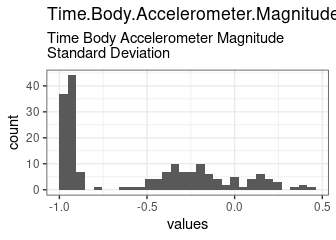

Distribution of values for Time.Body.Accelerometer.Magnitude.Standard.Deviation

0 missing values.

#### Summary statistics

| name | label | data_type | n_missing | complete_rate | min | median | max | mean | sd | hist |
| --- | --- | --- | --- | --- | --- | --- | --- | --- | --- | --- |
| Time.Body.Accelerometer.Magnitude.Standard.Deviation | Time Body Accelerometer Magnitude Standard Deviation | numeric | 0 | 1 | -0.99 | -0.61 | 0.43 | -0.5439087 | 0.4310448 | ▇▁▅▂▁ |

### Time.Gravity.Accelerometer.Magnitude.Mean

Time Gravity Accelerometer Magnitude Mean

#### Distribution

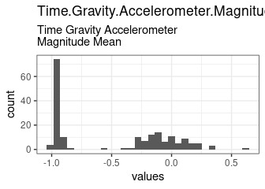

Distribution of values for Time.Gravity.Accelerometer.Magnitude.Mean

0 missing values.

#### Summary statistics

| name | label | data_type | n_missing | complete_rate | min | median | max | mean | sd | hist |
| --- | --- | --- | --- | --- | --- | --- | --- | --- | --- | --- |
| Time.Gravity.Accelerometer.Magnitude.Mean | Time Gravity Accelerometer Magnitude Mean | numeric | 0 | 1 | -0.99 | -0.48 | 0.64 | -0.4972897 | 0.4728834 | ▇▁▅▃▁ |

### Time.Gravity.Accelerometer.Magnitude.Standard.Deviation

Time Gravity Accelerometer Magnitude Standard Deviation

#### Distribution

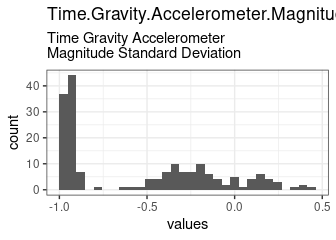

Distribution of values for Time.Gravity.Accelerometer.Magnitude.Standard.Deviation

0 missing values.

#### Summary statistics

| name | label | data_type | n_missing | complete_rate | min | median | max | mean | sd | hist |
| --- | --- | --- | --- | --- | --- | --- | --- | --- | --- | --- |
| Time.Gravity.Accelerometer.Magnitude.Standard.Deviation | Time Gravity Accelerometer Magnitude Standard Deviation | numeric | 0 | 1 | -0.99 | -0.61 | 0.43 | -0.5439087 | 0.4310448 | ▇▁▅▂▁ |

### Time.Body.Accelerometer.Jerk.Magnitude.Mean

Time Body Accelerometer Jerk Magnitude Mean

#### Distribution

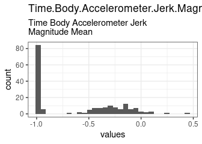

Distribution of values for Time.Body.Accelerometer.Jerk.Magnitude.Mean

0 missing values.

#### Summary statistics

| name | label | data_type | n_missing | complete_rate | min | median | max | mean | sd | hist |
| --- | --- | --- | --- | --- | --- | --- | --- | --- | --- | --- |
| Time.Body.Accelerometer.Jerk.Magnitude.Mean | Time Body Accelerometer Jerk Magnitude Mean | numeric | 0 | 1 | -0.99 | -0.82 | 0.43 | -0.6079296 | 0.3965272 | ▇▂▅▂▁ |

### Time.Body.Accelerometer.Jerk.Magnitude.Standard.Deviation

Time Body Accelerometer Jerk Magnitude Standard Deviation

#### Distribution

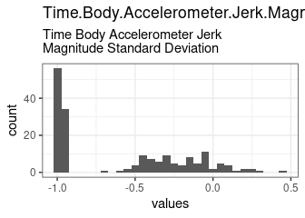

Distribution of values for Time.Body.Accelerometer.Jerk.Magnitude.Standard.Deviation

0 missing values.

#### Summary statistics

| name | label | data_type | n_missing | complete_rate | min | median | max | mean | sd | hist |
| --- | --- | --- | --- | --- | --- | --- | --- | --- | --- | --- |
| Time.Body.Accelerometer.Jerk.Magnitude.Standard.Deviation | Time Body Accelerometer Jerk Magnitude Standard Deviation | numeric | 0 | 1 | -0.99 | -0.8 | 0.45 | -0.5841756 | 0.4227953 | ▇▂▃▂▁ |

### Time.Body.Gyroscope.Magnitude.Mean

Time Body Gyroscope Magnitude Mean

#### Distribution

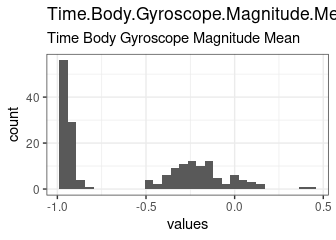

Distribution of values for Time.Body.Gyroscope.Magnitude.Mean

0 missing values.

#### Summary statistics

| name | label | data_type | n_missing | complete_rate | min | median | max | mean | sd | hist |
| --- | --- | --- | --- | --- | --- | --- | --- | --- | --- | --- |
| Time.Body.Gyroscope.Magnitude.Mean | Time Body Gyroscope Magnitude Mean | numeric | 0 | 1 | -0.98 | -0.66 | 0.42 | -0.5651631 | 0.3977338 | ▇▁▅▂▁ |

### Time.Body.Gyroscope.Magnitude.Standard.Deviation

Time Body Gyroscope Magnitude Standard Deviation

#### Distribution

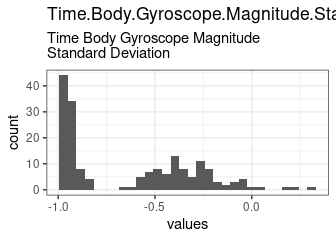

Distribution of values for Time.Body.Gyroscope.Magnitude.Standard.Deviation

0 missing values.

#### Summary statistics

| name | label | data_type | n_missing | complete_rate | min | median | max | mean | sd | hist |
| --- | --- | --- | --- | --- | --- | --- | --- | --- | --- | --- |
| Time.Body.Gyroscope.Magnitude.Standard.Deviation | Time Body Gyroscope Magnitude Standard Deviation | numeric | 0 | 1 | -0.98 | -0.74 | 0.3 | -0.6303947 | 0.3368827 | ▇▂▅▂▁ |

### Time.Body.Gyroscope.Jerk.Magnitude.Mean

Time Body Gyroscope Jerk Magnitude Mean

#### Distribution

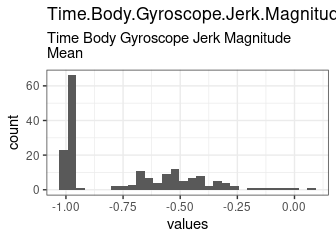

Distribution of values for Time.Body.Gyroscope.Jerk.Magnitude.Mean

0 missing values.

#### Summary statistics

| name | label | data_type | n_missing | complete_rate | min | median | max | mean | sd | hist |
| --- | --- | --- | --- | --- | --- | --- | --- | --- | --- | --- |
| Time.Body.Gyroscope.Jerk.Magnitude.Mean | Time Body Gyroscope Jerk Magnitude Mean | numeric | 0 | 1 | -1 | -0.86 | 0.088 | -0.7363693 | 0.2767541 | ▇▃▃▁▁ |

### Time.Body.Gyroscope.Jerk.Magnitude.Standard.Deviation

Time Body Gyroscope Jerk Magnitude Standard Deviation

#### Distribution

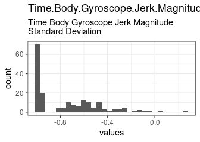

Distribution of values for Time.Body.Gyroscope.Jerk.Magnitude.Standard.Deviation

0 missing values.

#### Summary statistics

| name | label | data_type | n_missing | complete_rate | min | median | max | mean | sd | hist |
| --- | --- | --- | --- | --- | --- | --- | --- | --- | --- | --- |
| Time.Body.Gyroscope.Jerk.Magnitude.Standard.Deviation | Time Body Gyroscope Jerk Magnitude Standard Deviation | numeric | 0 | 1 | -1 | -0.88 | 0.25 | -0.7550152 | 0.2655057 | ▇▃▂▁▁ |

### Frequency.Body.Accelerometer.Mean.X

Frequency Body Accelerometer Mean X

#### Distribution

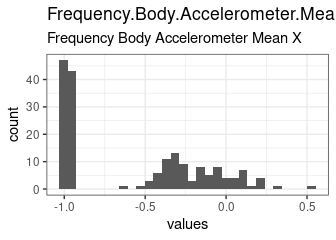

Distribution of values for Frequency.Body.Accelerometer.Mean.X

0 missing values.

#### Summary statistics

| name | label | data_type | n_missing | complete_rate | min | median | max | mean | sd | hist |
| --- | --- | --- | --- | --- | --- | --- | --- | --- | --- | --- |
| Frequency.Body.Accelerometer.Mean.X | Frequency Body Accelerometer Mean X | numeric | 0 | 1 | -1 | -0.77 | 0.54 | -0.5758 | 0.4300214 | ▇▁▃▂▁ |

### Frequency.Body.Accelerometer.Mean.Y

Frequency Body Accelerometer Mean Y

#### Distribution

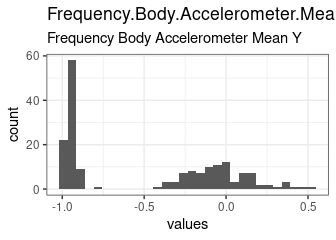

Distribution of values for Frequency.Body.Accelerometer.Mean.Y

0 missing values.

#### Summary statistics

| name | label | data_type | n_missing | complete_rate | min | median | max | mean | sd | hist |
| --- | --- | --- | --- | --- | --- | --- | --- | --- | --- | --- |
| Frequency.Body.Accelerometer.Mean.Y | Frequency Body Accelerometer Mean Y | numeric | 0 | 1 | -0.99 | -0.59 | 0.52 | -0.4887327 | 0.4806496 | ▇▁▃▃▁ |

### Frequency.Body.Accelerometer.Mean.Z

Frequency Body Accelerometer Mean Z

#### Distribution

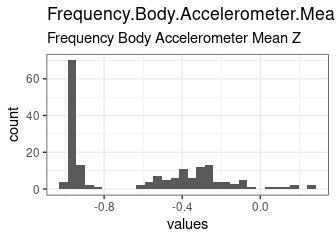

Distribution of values for Frequency.Body.Accelerometer.Mean.Z

0 missing values.

#### Summary statistics

| name | label | data_type | n_missing | complete_rate | min | median | max | mean | sd | hist |
| --- | --- | --- | --- | --- | --- | --- | --- | --- | --- | --- |
| Frequency.Body.Accelerometer.Mean.Z | Frequency Body Accelerometer Mean Z | numeric | 0 | 1 | -0.99 | -0.72 | 0.28 | -0.6297388 | 0.3556469 | ▇▂▅▁▁ |

### Frequency.Body.Accelerometer.Standard.Deviation.X

Frequency Body Accelerometer Standard Deviation X

#### Distribution

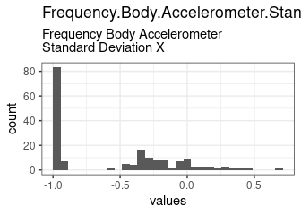

Distribution of values for Frequency.Body.Accelerometer.Standard.Deviation.X

0 missing values.

#### Summary statistics

| name | label | data_type | n_missing | complete_rate | min | median | max | mean | sd | hist |
| --- | --- | --- | --- | --- | --- | --- | --- | --- | --- | --- |
| Frequency.Body.Accelerometer.Standard.Deviation.X | Frequency Body Accelerometer Standard Deviation X | numeric | 0 | 1 | -1 | -0.75 | 0.66 | -0.5522011 | 0.4600233 | ▇▂▅▂▁ |

### Frequency.Body.Accelerometer.Standard.Deviation.Y

Frequency Body Accelerometer Standard Deviation Y

#### Distribution

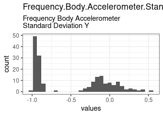

Distribution of values for Frequency.Body.Accelerometer.Standard.Deviation.Y

0 missing values.

#### Summary statistics

| name | label | data_type | n_missing | complete_rate | min | median | max | mean | sd | hist |
| --- | --- | --- | --- | --- | --- | --- | --- | --- | --- | --- |
| Frequency.Body.Accelerometer.Standard.Deviation.Y | Frequency Body Accelerometer Standard Deviation Y | numeric | 0 | 1 | -0.99 | -0.51 | 0.56 | -0.4814787 | 0.4740277 | ▇▁▅▃▁ |

### Frequency.Body.Accelerometer.Standard.Deviation.Z

Frequency Body Accelerometer Standard Deviation Z

#### Distribution

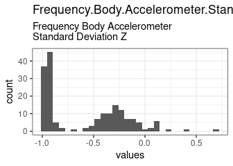

Distribution of values for Frequency.Body.Accelerometer.Standard.Deviation.Z

0 missing values.

#### Summary statistics

| name | label | data_type | n_missing | complete_rate | min | median | max | mean | sd | hist |
| --- | --- | --- | --- | --- | --- | --- | --- | --- | --- | --- |
| Frequency.Body.Accelerometer.Standard.Deviation.Z | Frequency Body Accelerometer Standard Deviation Z | numeric | 0 | 1 | -0.99 | -0.64 | 0.69 | -0.5823614 | 0.3880902 | ▇▃▅▁▁ |

### Frequency.Body.Accelerometer.Mean.Frequency.X

Frequency Body Accelerometer Mean Frequency X

#### Distribution

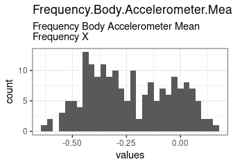

Distribution of values for Frequency.Body.Accelerometer.Mean.Frequency.X

0 missing values.

#### Summary statistics

| name | label | data_type | n_missing | complete_rate | min | median | max | mean | sd | hist |
| --- | --- | --- | --- | --- | --- | --- | --- | --- | --- | --- |
| Frequency.Body.Accelerometer.Mean.Frequency.X | Frequency Body Accelerometer Mean Frequency X | numeric | 0 | 1 | -0.64 | -0.26 | 0.16 | -0.2322661 | 0.1935684 | ▂▇▆▆▃ |

### Frequency.Body.Accelerometer.Mean.Frequency.Y

Frequency Body Accelerometer Mean Frequency Y

#### Distribution

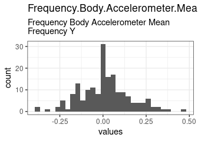

Distribution of values for Frequency.Body.Accelerometer.Mean.Frequency.Y

0 missing values.

#### Summary statistics

| name | label | data_type | n_missing | complete_rate | min | median | max | mean | sd | hist |
| --- | --- | --- | --- | --- | --- | --- | --- | --- | --- | --- |
| Frequency.Body.Accelerometer.Mean.Frequency.Y | Frequency Body Accelerometer Mean Frequency Y | numeric | 0 | 1 | -0.38 | 0.0079 | 0.47 | 0.0115289 | 0.1447051 | ▁▅▇▂▁ |

### Frequency.Body.Accelerometer.Mean.Frequency.Z

Frequency Body Accelerometer Mean Frequency Z

#### Distribution

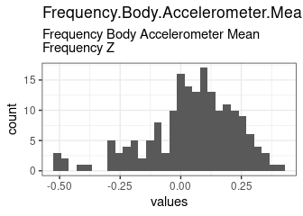

Distribution of values for Frequency.Body.Accelerometer.Mean.Frequency.Z

0 missing values.

#### Summary statistics

| name | label | data_type | n_missing | complete_rate | min | median | max | mean | sd | hist |
| --- | --- | --- | --- | --- | --- | --- | --- | --- | --- | --- |
| Frequency.Body.Accelerometer.Mean.Frequency.Z | Frequency Body Accelerometer Mean Frequency Z | numeric | 0 | 1 | -0.52 | 0.066 | 0.4 | 0.0437174 | 0.1850113 | ▁▂▆▇▃ |

### Frequency.Body.Accelerometer.Jerk.Mean.X

Frequency Body Accelerometer Jerk Mean X

#### Distribution

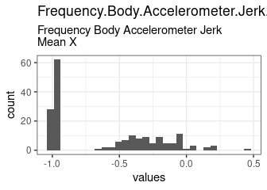

Distribution of values for Frequency.Body.Accelerometer.Jerk.Mean.X

0 missing values.

#### Summary statistics

| name | label | data_type | n_missing | complete_rate | min | median | max | mean | sd | hist |
| --- | --- | --- | --- | --- | --- | --- | --- | --- | --- | --- |
| Frequency.Body.Accelerometer.Jerk.Mean.X | Frequency Body Accelerometer Jerk Mean X | numeric | 0 | 1 | -0.99 | -0.81 | 0.47 | -0.6139282 | 0.3982896 | ▇▂▃▂▁ |

### Frequency.Body.Accelerometer.Jerk.Mean.Y

Frequency Body Accelerometer Jerk Mean Y

#### Distribution

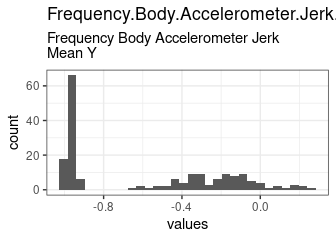

Distribution of values for Frequency.Body.Accelerometer.Jerk.Mean.Y

0 missing values.

#### Summary statistics

| name | label | data_type | n_missing | complete_rate | min | median | max | mean | sd | hist |
| --- | --- | --- | --- | --- | --- | --- | --- | --- | --- | --- |
| Frequency.Body.Accelerometer.Jerk.Mean.Y | Frequency Body Accelerometer Jerk Mean Y | numeric | 0 | 1 | -0.99 | -0.78 | 0.28 | -0.5881631 | 0.4077491 | ▇▁▃▃▁ |

### Frequency.Body.Accelerometer.Jerk.Mean.Z

Frequency Body Accelerometer Jerk Mean Z

#### Distribution

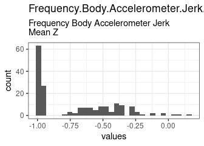

Distribution of values for Frequency.Body.Accelerometer.Jerk.Mean.Z

0 missing values.

#### Summary statistics

| name | label | data_type | n_missing | complete_rate | min | median | max | mean | sd | hist |
| --- | --- | --- | --- | --- | --- | --- | --- | --- | --- | --- |
| Frequency.Body.Accelerometer.Jerk.Mean.Z | Frequency Body Accelerometer Jerk Mean Z | numeric | 0 | 1 | -0.99 | -0.87 | 0.16 | -0.7143585 | 0.2970225 | ▇▂▃▁▁ |

### Frequency.Body.Accelerometer.Jerk.Standard.Deviation.X

Frequency Body Accelerometer Jerk Standard Deviation X

#### Distribution

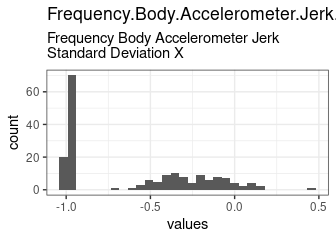

Distribution of values for Frequency.Body.Accelerometer.Jerk.Standard.Deviation.X

0 missing values.

#### Summary statistics

| name | label | data_type | n_missing | complete_rate | min | median | max | mean | sd | hist |
| --- | --- | --- | --- | --- | --- | --- | --- | --- | --- | --- |
| Frequency.Body.Accelerometer.Jerk.Standard.Deviation.X | Frequency Body Accelerometer Jerk Standard Deviation X | numeric | 0 | 1 | -1 | -0.83 | 0.48 | -0.6121033 | 0.4004506 | ▇▂▃▂▁ |

### Frequency.Body.Accelerometer.Jerk.Standard.Deviation.Y

Frequency Body Accelerometer Jerk Standard Deviation Y

#### Distribution

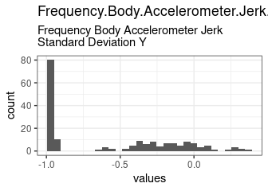

Distribution of values for Frequency.Body.Accelerometer.Jerk.Standard.Deviation.Y

0 missing values.

#### Summary statistics

| name | label | data_type | n_missing | complete_rate | min | median | max | mean | sd | hist |
| --- | --- | --- | --- | --- | --- | --- | --- | --- | --- | --- |
| Frequency.Body.Accelerometer.Jerk.Standard.Deviation.Y | Frequency Body Accelerometer Jerk Standard Deviation Y | numeric | 0 | 1 | -0.99 | -0.79 | 0.35 | -0.570731 | 0.4319873 | ▇▁▃▃▁ |

### Frequency.Body.Accelerometer.Jerk.Standard.Deviation.Z

Frequency Body Accelerometer Jerk Standard Deviation Z

#### Distribution

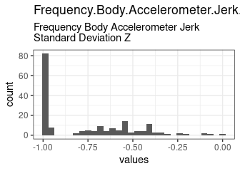

Distribution of values for Frequency.Body.Accelerometer.Jerk.Standard.Deviation.Z

0 missing values.

#### Summary statistics

| name | label | data_type | n_missing | complete_rate | min | median | max | mean | sd | hist |
| --- | --- | --- | --- | --- | --- | --- | --- | --- | --- | --- |
| Frequency.Body.Accelerometer.Jerk.Standard.Deviation.Z | Frequency Body Accelerometer Jerk Standard Deviation Z | numeric | 0 | 1 | -0.99 | -0.9 | -0.0062 | -0.7564894 | 0.2570577 | ▇▃▃▁▁ |

### Frequency.Body.Accelerometer.Jerk.Mean.Frequency.X

Frequency Body Accelerometer Jerk Mean Frequency X

#### Distribution

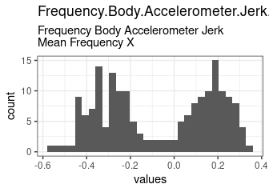

Distribution of values for Frequency.Body.Accelerometer.Jerk.Mean.Frequency.X

0 missing values.

#### Summary statistics

| name | label | data_type | n_missing | complete_rate | min | median | max | mean | sd | hist |
| --- | --- | --- | --- | --- | --- | --- | --- | --- | --- | --- |
| Frequency.Body.Accelerometer.Jerk.Mean.Frequency.X | Frequency Body Accelerometer Jerk Mean Frequency X | numeric | 0 | 1 | -0.58 | -0.061 | 0.33 | -0.0691018 | 0.2541022 | ▂▇▂▅▇ |

### Frequency.Body.Accelerometer.Jerk.Mean.Frequency.Y

Frequency Body Accelerometer Jerk Mean Frequency Y

#### Distribution

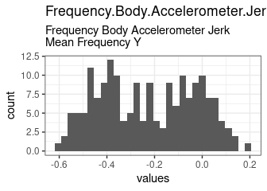

Distribution of values for Frequency.Body.Accelerometer.Jerk.Mean.Frequency.Y

0 missing values.

#### Summary statistics

| name | label | data_type | n_missing | complete_rate | min | median | max | mean | sd | hist |
| --- | --- | --- | --- | --- | --- | --- | --- | --- | --- | --- |
| Frequency.Body.Accelerometer.Jerk.Mean.Frequency.Y | Frequency Body Accelerometer Jerk Mean Frequency Y | numeric | 0 | 1 | -0.6 | -0.23 | 0.2 | -0.2281021 | 0.1998647 | ▅▇▆▇▃ |

### Frequency.Body.Accelerometer.Jerk.Mean.Frequency.Z

Frequency Body Accelerometer Jerk Mean Frequency Z

#### Distribution

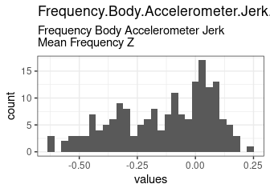

Distribution of values for Frequency.Body.Accelerometer.Jerk.Mean.Frequency.Z

0 missing values.

#### Summary statistics

| name | label | data_type | n_missing | complete_rate | min | median | max | mean | sd | hist |
| --- | --- | --- | --- | --- | --- | --- | --- | --- | --- | --- |
| Frequency.Body.Accelerometer.Jerk.Mean.Frequency.Z | Frequency Body Accelerometer Jerk Mean Frequency Z | numeric | 0 | 1 | -0.63 | -0.092 | 0.23 | -0.1376023 | 0.2078722 | ▂▅▃▇▅ |

### Frequency.Body.Gyroscope.Mean.X

Frequency Body Gyroscope Mean X

#### Distribution

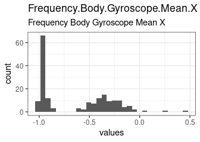

Distribution of values for Frequency.Body.Gyroscope.Mean.X

0 missing values.

#### Summary statistics

| name | label | data_type | n_missing | complete_rate | min | median | max | mean | sd | hist |
| --- | --- | --- | --- | --- | --- | --- | --- | --- | --- | --- |
| Frequency.Body.Gyroscope.Mean.X | Frequency Body Gyroscope Mean X | numeric | 0 | 1 | -0.99 | -0.73 | 0.47 | -0.6367396 | 0.3467628 | ▇▂▅▁▁ |

### Frequency.Body.Gyroscope.Mean.Y

Frequency Body Gyroscope Mean Y

#### Distribution

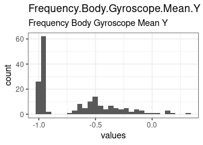

Distribution of values for Frequency.Body.Gyroscope.Mean.Y

0 missing values.

#### Summary statistics

| name | label | data_type | n_missing | complete_rate | min | median | max | mean | sd | hist |
| --- | --- | --- | --- | --- | --- | --- | --- | --- | --- | --- |
| Frequency.Body.Gyroscope.Mean.Y | Frequency Body Gyroscope Mean Y | numeric | 0 | 1 | -0.99 | -0.81 | 0.33 | -0.6766868 | 0.3319182 | ▇▃▃▁▁ |